# Features driving relocalisation to granules

Tom Smith

Cambridge Centre for Proteomics

18 September, 2023

Abstract

Here, we extract the features we belive may contribute to relocalisation to granules

```r
library(camprotR)
library(tidyverse)
library(MSnbase)
library(biomaRt)
library(ggbeeswarm)
library(coRdon)
```

Read in quantification and proportion objects.

```r
total_tx <- readRDS('../1_data_processing/out/transcript_quant_total_res.rds')

all_datasets <- readRDS('../3_proportional_localisation/results/all_datasets_final.rds')
proportions <- readRDS('../5_relocalisation/out/proportions_annot.rds')
proportions_per_rep <- readRDS('../3_proportional_localisation/results/proportions_per_rep.rds')
```

Determine mean transcript expression. We will use this downstream for codon optimality.

```r
tx_mean_exprs <- total_tx[,pData(total_tx)$condition=='DMSO'] %>% exprs() %>% rowMeans() %>%
  data.frame() %>%
  setNames('TPM')
```

Get transcript/gene lengths.

```r
all_tx_ids <- unique(c(rownames(all_datasets$transcript$DMSO$corrected),
                       rownames(all_datasets$transcript$Tg$corrected)))

all_gene_ids <- unique(c(rownames(all_datasets$gene$DMSO$corrected),
                         rownames(all_datasets$gene$Tg$corrected),
                         fData(all_datasets$transcript$DMSO$corrected)$ensembl_gene_id,
                         fData(all_datasets$transcript$Tg$corrected)$ensembl_gene_id))

print(length(all_gene_ids))
```

```
[1] 14684
```

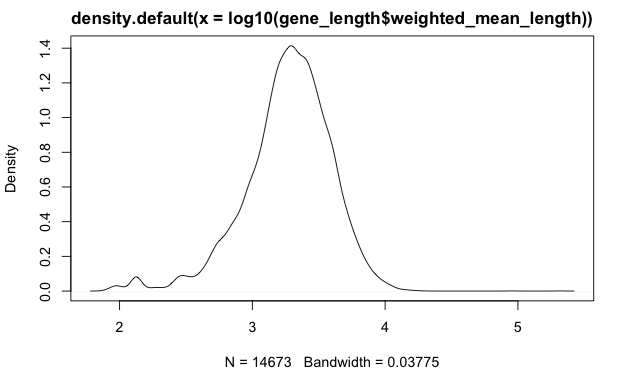

```r
ensembl <- useEnsembl(biomart="ensembl", version=102, dataset="hsapiens_gene_ensembl")

transcript_lengths <- getBM(attributes=c('ensembl_transcript_id',
                                         'ensembl_gene_id',
                                         'transcript_length',
                                         'transcript_tsl',
                                         'transcript_gencode_basic',
                                         'transcript_appris'),
                                         mart = ensembl,
                     filters = 'ensembl_gene_id',
                     values=all_gene_ids)


gene_length <- transcript_lengths %>% merge(tx_mean_exprs, by.x='ensembl_transcript_id', by.y='row.names') %>%
  filter(TPM>0) %>%
  mutate(norm_factor=TPM/sum(TPM)) %>% # create a weighting factor from the TPM for each transcript
  group_by(ensembl_gene_id) %>%
  summarise(weighted_mean_length=weighted.mean(transcript_length, norm_factor))

plot(density(log10(gene_length$weighted_mean_length)))
```

```r
summary(log10(gene_length$weighted_mean_length))
```

```
   Min. 1st Qu.  Median    Mean 3rd Qu.    Max.
  1.892   3.100   3.295   3.269   3.483   5.312
```

```r
rna_lengths <- list('gene'=tibble::column_to_rownames(tibble::remove_rownames(gene_length), 'ensembl_gene_id'),
                    'transcript'=tibble::column_to_rownames(
                      tibble::remove_rownames(transcript_lengths), 'ensembl_transcript_id'))
```

Identify the dominant localisation in control conditions

```r
major_loc_dmso <- proportions %>% lapply(function(x){
  x %>%
    filter(condition=='DMSO') %>%
    #tibble::column_to_rownames('id') %>%
    mutate(Nucleus=Nucleus+Nucleolus) %>%
    dplyr::select(id, Cytosol, Granule, Nucleus, Membrane) %>%
    pivot_longer(-id) %>%
    #filter(value>0.5) %>%
    group_by(id) %>%
    slice_max(order_by=value, n=1, with_ties=FALSE) %>%
    tibble::column_to_rownames('id') %>%
    setNames(c('major_localisation', 'proportion'))
  })

table(major_loc_dmso$gene$major_localisation)
```

```
 Cytosol  Granule Membrane  Nucleus
    7266     3378     2029      469
```

```r
table(major_loc_dmso$transcript$major_localisation)
```

```
 Cytosol  Granule Membrane  Nucleus
   17452     6651     4217     3519
```

Pivot major localisation into wide format

```r
major_loc_dmso_wide <- major_loc_dmso %>% lapply(function(x){
  x %>% mutate('present'=1) %>% dplyr::select(-proportion) %>%
    tibble::rownames_to_column('id') %>%
    pivot_wider(id_cols=id, names_from=major_localisation, values_from=present) %>%
    replace(is.na(.), 0) %>%
    tibble::column_to_rownames('id')
})
```

First, let’s consider some simple features like the length and localisation prior to stress (mem vs cyt). We’ll use the average localisations for this

```r
granule_relocalisation <- proportions %>% names() %>% lapply(function(level){

  proportions[[level]] %>%
    dplyr::select(id, condition, Granule, Signal_TM, uniprot_signal_tm, conservative_signal_tm) %>%
    pivot_wider(names_from=condition, values_from=Granule) %>%
    filter(is.finite(DMSO), is.finite(Tg)) %>%
    mutate(diff=Tg-DMSO) %>%
    merge(rna_lengths[[level]], by.x='id', by.y='row.names', all.x=TRUE) %>%
    merge(major_loc_dmso[[level]], by.x='id', by.y='row.names', all.x=TRUE)
})


names(granule_relocalisation) <- names(proportions)
```

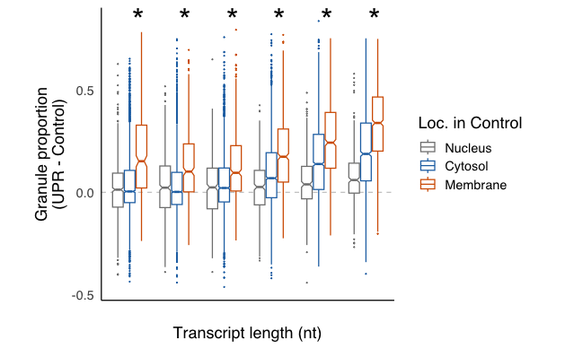

```r
# test that relocalisation for membrane RNAs is always higher than cytosol RNAs, regardless of length.
sig <- granule_relocalisation$transcript %>%
  mutate(binned_length=Hmisc::cut2(transcript_length, g=6)) %>%
  filter(major_localisation %in% c('Cytosol', 'Membrane')) %>%
  group_by(binned_length) %>%
  do(broom::tidy(wilcox.test(formula=diff~major_localisation, data=.))) %>%
  filter(p.value<0.001) %>%
  mutate(major_localisation='Membrane')


plot_length_vs_granule_reloc <- function(obj){
  obj %>%
    filter(major_localisation %in% c('Cytosol', 'Membrane', 'Nucleus')) %>%
    mutate(major_localisation=factor(major_localisation, levels=c('Nucleus', 'Cytosol', 'Membrane'))) %>%
    ggplot(aes(binned_length, diff, colour=major_localisation)) +
    geom_hline(yintercept=0, linetype=2, colour='grey80') +
    geom_boxplot(outlier.size=0.1, notch=TRUE) +
    theme_camprot(base_size=15, base_family='sans', border=FALSE) +
    scale_colour_manual(values=c('grey50', get_cat_palette(2)), name='Loc. in Control') +
    theme(axis.text.x=element_blank(),
          axis.ticks=element_blank()) +
    xlab('\nTranscript length (nt)') +
    ylab('Granule proportion\n(UPR - Control)')
}

to_plot <- granule_relocalisation$transcript %>%
  mutate(binned_length=Hmisc::cut2(transcript_length, g=6))

p <- to_plot %>%
  plot_length_vs_granule_reloc() +
  geom_text(data=sig, label='*', y=Inf, vjust=1, hjust=-0.2, colour='black', size=10)

print(p)
```

```r
range <- granule_relocalisation$transcript %>%
  filter(major_localisation %in% c('Cytosol', 'Membrane', 'Nucleus')) %>%
  pull(diff)

range <- range[is.finite(range)]

range_range <- max(range)-min(range)
tri_min <- max(range) - (range_range*1.15)
tri_max <- max(range) - (range_range*1.1)

p2 <- p +
  xlab('\n\n\n') +
  annotate(geom='polygon', x=c(1,6,6,1), y=c(tri_min, tri_min, tri_max, tri_min), fill='grey40')  +
  annotate(geom='text', x=3.5, y=(max(range) - (range_range*1.2)), label='Transcript length', size=5, vjust=0.5) +
  coord_cartesian(ylim=c(min(range), max(range)), clip = 'off')

print(p2)

ggsave('../../../../../5_manuscript_figures/Figure_5/features_granules/length_loc.png', p2, width=5, height=3.5)
```

[figure not shown]

```r
ggsave('../../../../../5_manuscript_figures/Figure_5/features_granules/length_loc.pdf', p2, width=5, height=3.5)
```

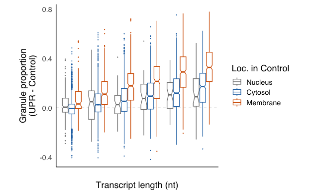

```r
granule_relocalisation$gene %>%
  filter(is.finite(weighted_mean_length)) %>%
  mutate(binned_length=Hmisc::cut2(weighted_mean_length, g=6)) %>%
  plot_length_vs_granule_reloc()
```

OK, so a clear relationship between RNA length and relocalisation to granule.

Tabulate the number of RNAs in each category above.

| binned_length | n_Cytosol | n_Membrane | n_Nucleus | statistic | p.value | method | alternative | major_localisation |
| --- | --- | --- | --- | --- | --- | --- | --- | --- |
| [ 80, 657) | 2901 | 324 | 813 | 264668.5 | 3.716189e-38 | Wilcoxon rank sum test with continuity correction | two.sided | Membrane |
| [ 657, 1008) | 3074 | 373 | 585 | 361592.0 | 1.952040e-31 | Wilcoxon rank sum test with continuity correction | two.sided | Membrane |
| [1008, 1759) | 3287 | 503 | 415 | 575826.0 | 4.975621e-28 | Wilcoxon rank sum test with continuity correction | two.sided | Membrane |
| [1759, 2653) | 2974 | 707 | 343 | 724554.0 | 7.137817e-38 | Wilcoxon rank sum test with continuity correction | two.sided | Membrane |
| [2653, 4220) | 2603 | 747 | 327 | 682340.0 | 1.582826e-35 | Wilcoxon rank sum test with continuity correction | two.sided | Membrane |
| [4220,91667] | 1461 | 913 | 346 | 422079.0 | 2.530675e-51 | Wilcoxon rank sum test with continuity correction | two.sided | Membrane |

Next, let’s add in the TM/Signal annotations

```r
plot_length_vs_granule_reloc <- function(obj){
  obj %>%
    filter(major_localisation %in% c('Cytosol', 'Membrane')) %>%
    filter(!is.na(Signal_TM)) %>%
    ggplot(aes(binned_length, diff, colour=Signal_TM)) +
    geom_hline(yintercept=0, linetype=2, colour='grey80') +
    #geom_quasirandom(aes(group=Signal_TM), dodge.width=0.75, size=0.5) +
    geom_boxplot(outlier.size=0.1) +
    theme_camprot() +
    scale_colour_manual(values=c('grey20', get_cat_palette(3)), name='Loc. in DMSO') +
    theme(axis.text.x=element_text(angle=45, vjust=1, hjust=1)) +
    xlab('Transcript length (nt)') +
    ylab('Granule proportion\n(Tg - DMSO)')
}
p <- granule_relocalisation$transcript %>%
  mutate(binned_length=Hmisc::cut2(transcript_length, g=6)) %>%
  plot_length_vs_granule_reloc()
print(p + facet_wrap(~major_localisation))
print(p + facet_wrap(~(ifelse(conservative_signal_tm, 'Signal/TM', 'No Signal/TM'))) + aes(colour=major_localisation))

p <- granule_relocalisation$gene %>%
  filter(is.finite(weighted_mean_length)) %>%
  mutate(binned_length=Hmisc::cut2(weighted_mean_length, g=6)) %>%
  plot_length_vs_granule_reloc()
print(p + facet_wrap(~major_localisation))
print(p + facet_wrap(~(ifelse(conservative_signal_tm, 'Signal/TM', 'No Signal/TM'))) + aes(colour=major_localisation))
```

[output not shown]

OK, so no real strong relationship between annotated signal/TM and granule relocalisation. If anything, signal/TM in shorter transcripts is predictive of more relocalisation to granules.

```r
go_human <- readRDS('../../../../../1_external/10_GO/all_go_genes_expanded.rds')
er_ga_genes <- go_human %>%
  filter(go_id %in% c('GO:0005794','GO:0005783')) %>%
  pull(ensembl_gene_id) %>%
  unique()
length(er_ga_genes)
```

```r
to_plot <- granule_relocalisation$transcript %>%
  filter(ensembl_gene_id %in% er_ga_genes) %>%
  mutate(binned_length=Hmisc::cut2(transcript_length, g=6))

p <- plot_length_vs_granule_reloc(to_plot)

print(p +
        facet_wrap(~(ifelse(conservative_signal_tm, 'Signal/TM', 'No Signal/TM'))) + aes(colour=major_localisation))
```

Next step is to add the eCLIP data

```r
eCLIP_wide <- readRDS('../../../../../1_external/1_ENCORE_eCLIP/out/eCLIP_wide.rds')
eCLIP_wide %>% lapply(dim)
```

Restrict to proteins with at least 100 bound targets

```r
eCLIP_to_model <- granule_relocalisation %>%
  names() %>%
  lapply(function(level){

    eclip_data <- eCLIP_wide[[level]][,colSums(eCLIP_wide[[level]])>100]
    eclip_data <- eclip_data[rowSums(eclip_data)>0,]

    to_model <- granule_relocalisation[[level]] %>%
      merge(eclip_data, by.x='id', by.y='row.names', all.x=TRUE) %>%
      merge(major_loc_dmso_wide[[level]], by.x='id', by.y='row.names', all.x=TRUE)

    to_model[,colnames(eclip_data)][is.na(to_model[,colnames(eclip_data)])] <- 0

    return(to_model)
  })

names(eCLIP_to_model) <- names(granule_relocalisation)
lapply(eCLIP_to_model, dim)
```

The final step is to add the sequence features and run this as one penalised regression and do a train, test split so we can assess accuracy of prediction. We’ll gather the features here and perform the regression in the next notebook.

In addition to the above, we will also add IRES and uORF annotations and lengths for 5’ and 3’ UTRs

We need the transcript sequences. We will only model at the transcript level given sequence features don’t really makes sense at the gene level.

```r
ensembl <- useEnsembl(biomart="ensembl", version=102, dataset="hsapiens_gene_ensembl")

transcript_seq <- getBM(attributes=c('cdna', 'ensembl_transcript_id'), mart=ensembl, filters='ensembl_transcript_id',
                    values=unique(proportions$transcript$id))

print(dim(transcript_seq))
transcript_seq <- transcript_seq %>% unique()
print(dim(transcript_seq))
```

```r
utr5_seq <- getBM(attributes=c('5utr', 'ensembl_transcript_id'), mart=ensembl, filters='ensembl_transcript_id',
                    values=unique(proportions$transcript$id))

utr3_seq <- getBM(attributes=c('3utr', 'ensembl_transcript_id'), mart=ensembl, filters='ensembl_transcript_id',
                    values=unique(proportions$transcript$id))

coding_seq <- getBM(attributes=c('coding', 'ensembl_transcript_id'), mart=ensembl, filters='ensembl_transcript_id',
                    values=unique(proportions$transcript$id))

transcript_region_seq <- list('utr5'=utr5_seq, 'utr3'=utr3_seq, 'coding'=coding_seq)
```

```r
utr5_length <- utr5_seq %>%
  mutate(utr5_length=log10(nchar(`5utr`))) %>%
  dplyr::select(utr5_length, ensembl_transcript_id)

plot(density(utr5_length$utr5_length))

utr3_length <- utr3_seq %>%
  mutate(utr3_length=log10(nchar(`3utr`))) %>%
  dplyr::select(utr3_length, ensembl_transcript_id)

plot(density(utr3_length$utr3_length))

coding_length <- coding_seq %>%
  mutate(coding_length=log10(nchar(`coding`))) %>%
  dplyr::select(coding_length, ensembl_transcript_id)

plot(density(coding_length$coding_length))
```

Obtain kmers for each RNA region.

```r
min_k <- 1
max_k <- 6

kmers_per_region <- transcript_region_seq %>% names() %>% lapply(function(name){

  region_seq <- transcript_region_seq[[name]]
  region_with_seq <- region_seq[region_seq[,1]!="Sequence unavailable",]

  region_rnaseq <- region_with_seq[,1] %>%
    gsub(pattern='T', replacement='U') %>%
    Biostrings::RNAStringSet()


  kmers <- lapply(seq(min_k, max_k), function(k){
    print(k)
    # as.prob=TRUE so this is frequency rather than count
    Biostrings::oligonucleotideFrequency(region_rnaseq, width=k, as.prob=TRUE) %>%
      data.frame()
  })

  kmers <- bind_cols(kmers)
  kmers$AU_content <- kmers$A+kmers$U
  colnames(kmers) <- paste(name, colnames(kmers), sep='.')
  rownames(kmers) <- region_with_seq$ensembl_transcript_id

  return(kmers)
})

constant_transcripts <- intersect(intersect(rownames(kmers_per_region[[1]]),
                                            rownames(kmers_per_region[[2]])),
                                                     rownames(kmers_per_region[[3]]))

length(constant_transcripts)
kmers_per_region <- kmers_per_region %>% lapply(function(x) x[constant_transcripts,]) %>% bind_cols()
dim(kmers_per_region)
```

codon usage

```r
region_seq <- transcript_region_seq$coding
region_with_seq <- region_seq[region_seq[,1]!="Sequence unavailable",]

region_rnaseq <- region_with_seq[,1] %>%
  gsub(pattern='T', replacement='U') %>%
  Biostrings::RNAStringSet()


codon_kmers <- Biostrings::oligonucleotideFrequency(region_rnaseq, width=3, step=3, as.prob=TRUE) %>%
    data.frame()

colnames(codon_kmers) <- paste0('codon_', colnames(codon_kmers))
rownames(codon_kmers) <- region_with_seq$ensembl_transcript_id
```

codon dinuc and final nuc (wobble position)

```r
region_seq <- transcript_region_seq$coding
region_with_seq <- region_seq[region_seq[,1]!="Sequence unavailable",]

region_rnaseq <- region_with_seq[,1] %>%
  gsub(pattern='T', replacement='U') %>%
  sapply(function(x) substr(x, 3, nchar(x))) %>%
  Biostrings::RNAStringSet()

codon_wobble <- Biostrings::oligonucleotideFrequency(region_rnaseq, width=1, step=3, as.prob=TRUE) %>%
    data.frame()

colnames(codon_wobble) <- paste0('wobble_', colnames(codon_wobble))
rownames(codon_wobble) <- region_with_seq$ensembl_transcript_id
```

```r
region_seq <- transcript_region_seq$coding
region_with_seq <- region_seq[region_seq[,1]!="Sequence unavailable",]

region_rnaseq <- region_with_seq[,1] %>%
  gsub(pattern='T', replacement='U') %>%
  sapply(function(x) substr(x, 2, nchar(x))) %>%
  Biostrings::RNAStringSet()

codon_dinuc <- Biostrings::oligonucleotideFrequency(region_rnaseq, width=2, step=3, as.prob=TRUE) %>%
    data.frame()

colnames(codon_dinuc) <- paste0('codondinuc_', colnames(codon_dinuc))
rownames(codon_dinuc) <- region_with_seq$ensembl_transcript_id
```

Codon optimality. Here, we use MILC as our metric and compute vs all transcript and vs top 1% most abundant (by TPM)

```r
region_seq <- transcript_region_seq$coding
region_with_seq <- region_seq[region_seq[,1]!="Sequence unavailable",]

region_rnaseq <- region_with_seq[,1] %>%
  Biostrings::DNAStringSet()

names(region_rnaseq) <- region_with_seq$ensembl_transcript_id

abundant_tx <- tx_mean_exprs %>% arrange(desc(TPM)) %>% head(nrow(tx_mean_exprs)*0.01) %>% row.names()

ct <- suppressWarnings(codonTable(region_rnaseq))

ct_abundant <- suppressWarnings(codonTable(region_rnaseq[intersect(abundant_tx,
                                                                   region_with_seq$ensembl_transcript_id),]))

milc <- MILC(ct, subsets=list('abundant'=ct_abundant))
colnames(milc) <- c('milc_all', 'milc_abundant')

plot(milc) # very highly correlated as we would expect
head(milc)
rownames(milc) <- region_with_seq$ensembl_transcript_id
```

5’ AUG in/out of frame

```r
region_seq <- transcript_region_seq$utr5
region_with_seq <- region_seq[region_seq[,1]!="Sequence unavailable",]

region_rnaseq_rev <- region_with_seq[,1] %>%
  lapply(function(x) rev(x)) %>%
  gsub(pattern='T', replacement='U') %>%
  Biostrings::RNAStringSet() %>%
  Biostrings::reverse()

rev_in_frame_5_utr_codons <- Biostrings::oligonucleotideFrequency(region_rnaseq_rev, width=3, step=3, as.prob=TRUE) %>%
    data.frame()

in_frame_start <- rev_in_frame_5_utr_codons[,'GUA',drop=FALSE] %>%
  setNames('inframe_AUG')

rev_all_frame_5_utr_codons <- Biostrings::oligonucleotideFrequency(region_rnaseq_rev, width=3, as.prob=TRUE) %>%
    data.frame()

all_frame_start <- rev_all_frame_5_utr_codons[,'GUA',drop=FALSE] %>%
  setNames('allframe_AUG')


AUG_frames <- bind_cols(in_frame_start, all_frame_start) %>%
  mutate(outframe_AUG=allframe_AUG-(inframe_AUG/3)) %>%
  dplyr::select(-allframe_AUG)

rownames(AUG_frames) <- region_with_seq$ensembl_transcript_id
plot(density(AUG_frames$inframe_AUG))
plot(density(AUG_frames$outframe_AUG))
```

Merge together the sequence features.

```r
dim(codon_dinuc)
dim(codon_wobble)
dim(codon_kmers)
dim(AUG_frames)
dim(kmers_per_region)



colnames(kmers_per_region)[grepl('codon', colnames(kmers_per_region))]

kmers_per_region <- bind_cols(kmers_per_region,
    codon_kmers[rownames(kmers_per_region),],
    codon_wobble[rownames(kmers_per_region),],
    codon_dinuc[rownames(kmers_per_region),],
    AUG_frames[rownames(kmers_per_region),])

dim(kmers_per_region)
saveRDS(codon_kmers, './out/codon_kmers.rds')
```

Scale the features

```r
gc()

kmers_per_region <- scale(kmers_per_region)
gc()
```

We also want to add predicted uORFs and IRES

```r
uORF_db <- readxl::read_excel('../../../../../1_external/8_uORF/Supplemental_Data_Tables_.xlsx', sheet=5, skip=2) %>%
  separate(uORF_ID, into=c('ensembl_transcript_id'), remove=FALSE)

uORF_transcripts <- uORF_db %>%
  filter(type=='UTRonly', start_codon=='ATG', as.numeric(uORF_score)>5) %>%
  pull(ensembl_transcript_id)

ires_transcripts <- readRDS('../../../../../1_external/7_IRES/ires_gr_transcripts.rds') %>%
  pull(seqnames) %>%
  unique()
```

```r
eclip_cols <- colnames(eCLIP_to_model$transcript)[grepl('(_HepG2|_K562)', colnames(eCLIP_to_model$transcript))]

localisations <- colnames(major_loc_dmso_wide$transcript)

transcript_features <- eCLIP_to_model$transcript %>%
  filter(is.finite(uniprot_signal_tm), is.finite(conservative_signal_tm), is.finite(transcript_length)) %>%
  mutate(transcript_length=log10(transcript_length)) %>%
  tibble::column_to_rownames('id') %>%
  dplyr::select(diff, 'conservative_signal_tm', 'transcript_length', eclip_cols, localisations)

for(localisation in localisations){
  for(eclip_target in eclip_cols){
    name <- paste(localisation, eclip_target, sep=':')
    interaction <- transcript_features[[localisation]] * transcript_features[[eclip_target]]
    if(sum(interaction)>100){
      transcript_features[[name]] <- interaction
    }
  }

}

print(dim(transcript_features))
transcript_features <- merge(transcript_features, kmers_per_region, by='row.names') %>%
  mutate(IRES=Row.names %in% ires_transcripts,
         uORF=Row.names %in% uORF_transcripts)

print(dim(transcript_features))
colnames(transcript_features)[grepl('length', colnames(transcript_features), ignore.case=T)]
```

Add the UTR and coding lengths, plus the interactions between localisation and length

```r
transcript_features <- transcript_features %>%
  merge(utr5_length, by.x='Row.names', by.y='ensembl_transcript_id') %>%
  merge(utr3_length, by.x='Row.names', by.y='ensembl_transcript_id') %>%
  merge(coding_length, by.x='Row.names', by.y='ensembl_transcript_id') %>%
  merge(milc, by.x='Row.names', by.y='row.names') %>%
  tibble::column_to_rownames('Row.names')

print(dim(transcript_features))

for(localisation in localisations){
  transcript_features[[paste0(localisation, ':transcript_length')]] <- (
    transcript_features[[localisation]] * transcript_features$transcript_length)
  transcript_features[[paste0(localisation, ':utr5_length')]] <- (
    transcript_features[[localisation]] * transcript_features$utr5_length)
  transcript_features[[paste0(localisation, ':utr3_length')]] <- (
    transcript_features[[localisation]] * transcript_features$utr3_length)
  transcript_features[[paste0(localisation, ':coding_length')]] <- (
    transcript_features[[localisation]] * transcript_features$coding_length)
}

print(dim(transcript_features))
```

Save tx features to model in next notebook.

```r
saveRDS(transcript_features, './out/transcript_features.rds')
```